# Aplicación 2.9: Mix econométrico (datos espaciales, forma funcional, inferencia estadística y predicción)

## Medición de la calidad de vida

La renta per cápita es la forma más usual de cuantificar el nivel de bienestar de un país, permitiendo además la comparación entre distintas economías, independientemente de su tamaño. Sin embargo, utilizar sólo el PIB de los habitantes de un territorio como indicador del bienestar social y del progreso del país resulta bastante inapropiado, como se reconoce en el [Informe Stiglitz-Sen-Fitoussi](https://ec.europa.eu/eurostat/documents/8131721/8131772/Stiglitz-Sen-Fitoussi-Commission-report.pdf) del año 2009.

Distintos organismos, como la OCDE, las Naciones Unidas o la Comisión Europea, han reconocido la debilidad del PIB o la renta per cápita para valorar el nivel de desarrollo humano de una sociedad, proponiendo distintas alternativas para determinar la calidad de vida de las personas que residen en un determinado territorio.

Para este ejercicio utilizaremos los datos del año 2021 elaborados por las Naciones Unidas para construir el *Índice de Desarrollo Humano* (https://hdr.undp.org/data-center/human-development-index#/indicies/HDI), que es un indicador de bienestar agregado de los países (con escala entre 0 y 100) que engloba tanto los niveles de salud [medida por la variable *LifeExp*, la esperanza de vida al nacer, medida en años] y educación [medida por la variable *ExpEduc*, el grado de escolarización esperado para cada persona, medido en años] como el nivel económico de cada país [medido por la variable *GNIpc*, la renta per cápita, medida en dólares constantes en términos de paridad de poder adquisitivo].

## Código R

```r
# Lectura de librerías
library(tidyverse)
library(readxl)
library(sf)
library(geojsonsf)
library(viridis)
library(car)
library(alr4)
# Lectura de los datos
datos <- read_excel("data/HDI.xlsx")
summary(datos[,2:5])
```

```
      HDI           LifeExp         ExpEduc           GNIpc
 Min.   :38.50   Min.   :52.53   Min.   : 5.543   Min.   :   731.8
 1st Qu.:59.95   1st Qu.:65.75   1st Qu.:11.601   1st Qu.:  4592.9
 Median :73.90   Median :71.69   Median :13.405   Median : 12306.3
 Mean   :72.06   Mean   :71.31   Mean   :13.535   Mean   : 20249.1
 3rd Qu.:83.50   3rd Qu.:76.70   3rd Qu.:15.624   3rd Qu.: 30079.8
 Max.   :96.20   Max.   :85.47   Max.   :21.055   Max.   :146829.7
```

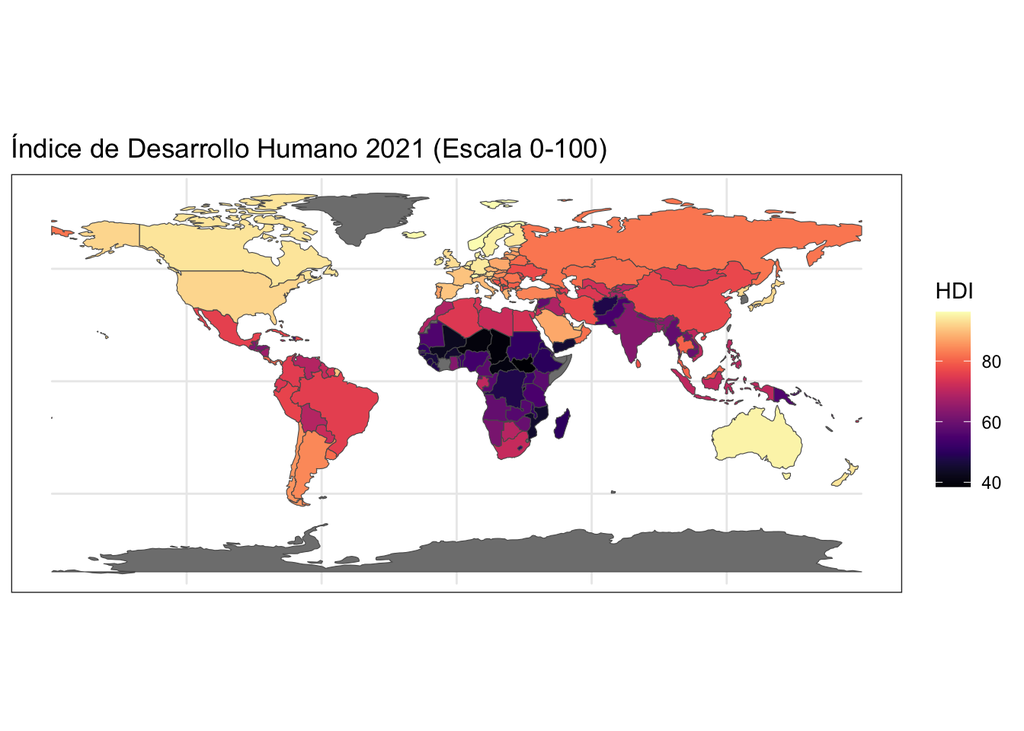

```r
# Lectura del mapa
mapa <- geojson_sf("data/WORLDmap.geojson")
# Fusión de datos y mapa
datos_geo <- left_join(mapa, datos, by = "name")
# Gráfica del HDI
ggplot(datos_geo) +
    geom_sf(aes(fill=HDI)) +
    theme_bw() +
    labs(title = "Índice de Desarrollo Humano 2021 (Escala 0-100)") +
    scale_fill_viridis(option="magma")
```

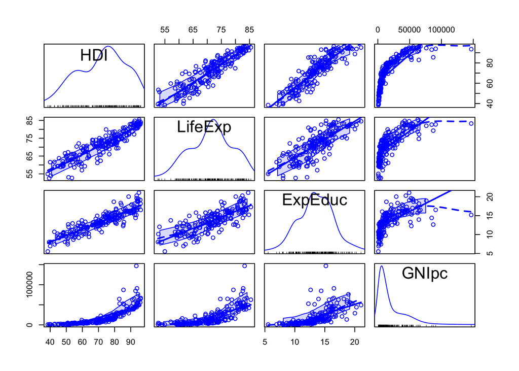

```r
# Regresión para explicar la variable HDI:
# HDI = f(LifeExp, ExpEduc, GNIpc) + e
# Gráficas parciales
# Variables originales
scatterplotMatrix(~ HDI + LifeExp + ExpEduc + GNIpc, data=datos)
```

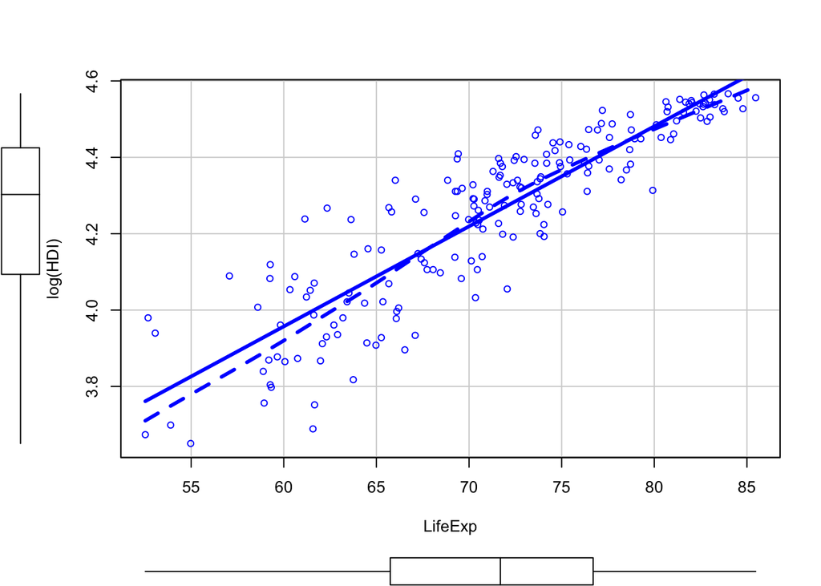

```r
# Variables transformadas
scatterplot(log(HDI) ~ LifeExp, data=datos,
            smooth=list(smoother=loessLine, var=FALSE, lwd.smooth=3),
            col="blue", regLine=list(lwd=3))
```

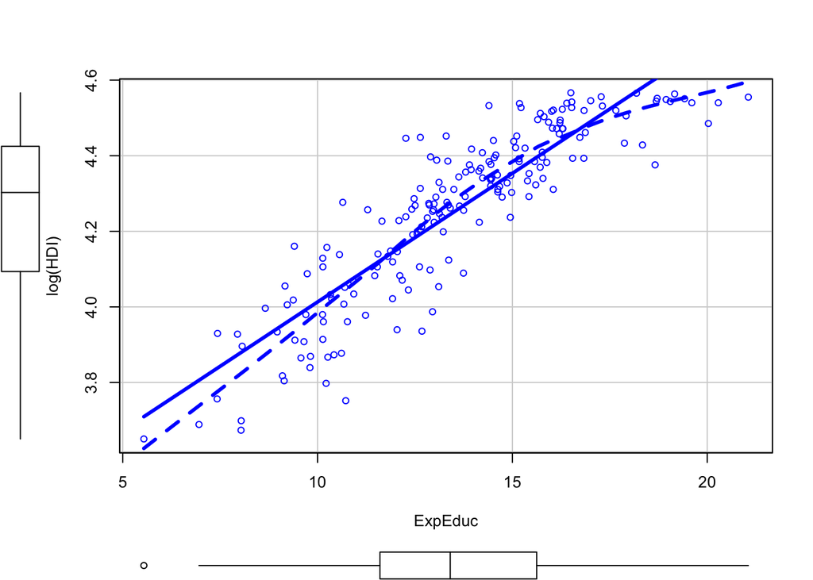

```r
scatterplot(log(HDI) ~ ExpEduc, data=datos,
            smooth=list(smoother=loessLine, var=FALSE, lwd.smooth=3),
            col="blue", regLine=list(lwd=3))
```

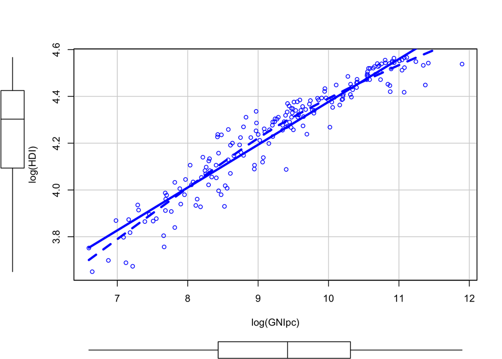

```r
scatterplot(log(HDI) ~ log(GNIpc), data=datos,
            smooth=list(smoother=loessLine, var=FALSE, lwd.smooth=3),
            col="blue", regLine=list(lwd=3))
```

```r
# Regresión por MCO del modelo
# log(HDI) = beta1 + beta2*LifeExp + beta3*ExpEduc + beta4*log(GNIpc) + e
# Interpretación beta2 y beta3: semi-elasticidades
# Interpretación beta4: elasticidad
mod_log <- lm(log(HDI) ~ LifeExp + ExpEduc + log(GNIpc), data = datos)
summary(mod_log)
```

```
Call:
lm(formula = log(HDI) ~ LifeExp + ExpEduc + log(GNIpc), data = datos)

Residuals:
      Min        1Q    Median        3Q       Max
-0.133214 -0.023027  0.004089  0.032086  0.105939

Coefficients:
             Estimate Std. Error t value Pr(>|t|)
(Intercept) 2.5298416  0.0352821  71.703  < 2e-16 ***
LifeExp     0.0064339  0.0008519   7.552 1.84e-12 ***
ExpEduc     0.0206765  0.0020530  10.072  < 2e-16 ***
log(GNIpc)  0.1056086  0.0059811  17.657  < 2e-16 ***
---
Signif. codes:  0 '***' 0.001 '**' 0.01 '*' 0.05 '.' 0.1 ' ' 1

Residual standard error: 0.046 on 187 degrees of freedom
Multiple R-squared:  0.9587,    Adjusted R-squared:  0.958
F-statistic:  1445 on 3 and 187 DF,  p-value: < 2.2e-16
```

```r
# Intervalo de confianza del 95% para los parámetros del modelo
confint(mod_log, level=.95)
```

```
                  2.5 %     97.5 %
(Intercept) 2.460239566 2.59944364
LifeExp     0.004753341 0.00811453
ExpEduc     0.016626586 0.02472649
log(GNIpc)  0.093809495 0.11740775
```

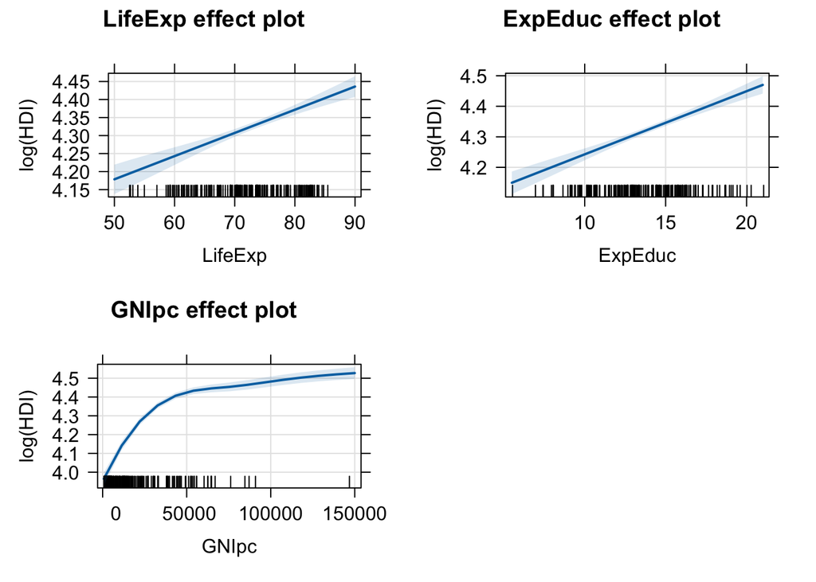

```r
# Gráficos de efectos
plot(allEffects(mod_log), grid=TRUE, rug=TRUE)
```

```r
# Inferencia estadística: contraste de la hipótesis {beta2<=beta3}
# Test t específico: H_0:{beta2-beta3<=0}
# t_0 = (beta2-beta3-0)/se(beta2-beta3)
b2 <- coef(mod_log)[[2]] # estimación del parámetro beta2
b3 <- coef(mod_log)[[3]] # estimación del parámetro beta3
varb2 <- vcov(mod_log)[2,2] # estim. var(beta2)
varb3 <- vcov(mod_log)[3,3] # estim. var(beta3)
covb2b3 <- vcov(mod_log)[2,3] # estim. cov(beta2,beta3)
se_beta2_menos_beta3 <- sqrt(varb2 + varb3 - 2 * covb2b3)
t_0 <- (b2-b3)/se_beta2_menos_beta3
cat("Estadístico t0 = ", round(t_0,3))
```

```
Estadístico t0 =  -5.814
```

```r
df <- df.residual(mod_log)
pval = 1-pt(t_0,df)
cat("p-valor = ", round(pval,3))
```

```
p-valor =  1
```

```r
# Test t general de la hipótesis {R*beta (>)(=)(<) r}
# Definición del contraste
t_test<-function(model,R,r){
  VCOV<-vcov(model)
  Rbeta<-as.numeric(t(R) %*% coef(model))
  varRbeta<-as.numeric(t(R) %*% VCOV %*% R)
  t_0<-(Rbeta-r)/sqrt(varRbeta)
  df<-df.residual(model)
  pval_unilat_izqda = pt(t_0,df)
  pval_bilat = 2*(1-pt(abs(t_0),df))
  pval_unilat_dcha = 1-pt(t_0,df)
  list<-c(t_0, pval_unilat_izqda, pval_bilat, pval_unilat_dcha)
  return(list)
}
# Ejecución del contraste
R <- c(0,1,-1,0)
r <- 0
p <- t_test(mod_log,R,r)
cat(" Estadístico t0 = ",p[[1]],"\n",
    " p-valor unilat_izqda  (Ho: Rbeta >= r) = ",p[[2]],"\n",
    " p-valor bilateral     (Ho: Rbeta = r)  = ",p[[3]],"\n",
    " p-valor unilat_dcha   (Ho: Rbeta <= r)  = ",p[[4]]," ")
```

```
 Estadístico t0 =  -5.814319
  p-valor unilat_izqda  (Ho: Rbeta >= r) =  1.294589e-08
  p-valor bilateral     (Ho: Rbeta = r)  =  2.589178e-08
  p-valor unilat_dcha   (Ho: Rbeta <= r)  =  1
```

```r
# Predicción del HDI para un país con los siguientes indicadores parciales:
# LifeExp = 71.7, ExpEduc = 13.4, GNIpc = 12306.3
nuevo_PAIS <- data.frame(LifeExp=c(71.7), ExpEduc=c(13.4), GNIpc=c(12306.3))
nuevo_PAIS
```

```
  LifeExp ExpEduc   GNIpc
1    71.7    13.4 12306.3
```

```r
# HDI esperado con intervalo de confianza
pred_log_HDI_IC <- predict(mod_log,  nuevo_PAIS,
                          interval="confidence", level=0.95)
pred_log_HDI_IC
```

```
       fit      lwr     upr
1 4.262828 4.256127 4.26953
```

```r
pred_HDI_IC=exp(pred_log_HDI_IC)
pred_HDI_IC
```

```
       fit      lwr      upr
1 71.01054 70.53624 71.48802
```

## Código Python

```python
# Lectura de librerías
import numpy as np
import pandas as pd
import geopandas as gpd
import matplotlib.pyplot as plt
import seaborn as sns
import scipy as sp
import scipy.stats as scs
import statsmodels.api as sm
import statsmodels.formula.api as smf
# Lectura de los datos
datos = pd.read_excel('data/HDI.xlsx')
datos.describe()
```

```
              HDI    LifeExp     ExpEduc          GNIpc
count  191.000000  191.00000  191.000000     191.000000
mean    72.057592   71.31286   13.534658   20249.088223
std     15.066063    7.64596    2.923911   21825.277076
min     38.500000   52.52540    5.542510     731.786709
25%     59.950000   65.74720   11.601258    4592.919612
50%     73.900000   71.69400   13.404920   12306.341000
75%     83.500000   76.69930   15.623665   30079.789725
max     96.200000   85.47340   21.054590  146829.700600
```

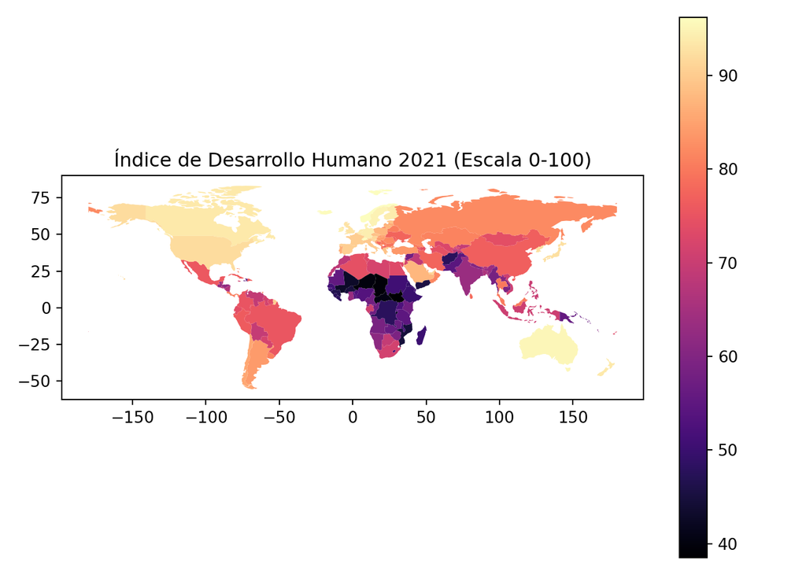

```python
# Lectura del mapa
mapa = gpd.read_file("data/WORLDmap.geojson")
# Fusión de datos y mapa
datos_geo  = mapa.merge(datos, on = 'name', how = 'left')
# Gráfica del HDI
fig, ax = plt.subplots(1,1)
datos_geo.plot(column="HDI",
           legend=True,
           cmap='magma',
           ax=ax)
plt.title('Índice de Desarrollo Humano 2021 (Escala 0-100)')
plt.tight_layout()
plt.show()
```

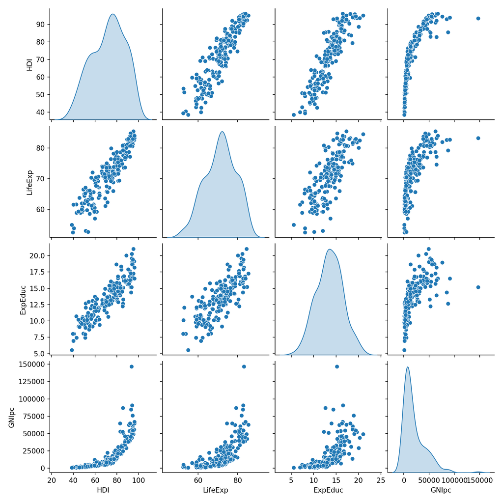

```python
# Regresión para explicar la variable HDI:
# HDI = f(LifeExp, ExpEduc, GNIpc) + e
# Gráficas parciales
# Variables originales
plt.figure(2)
sns.pairplot(data = datos, diag_kind = 'kde');
plt.show()
```

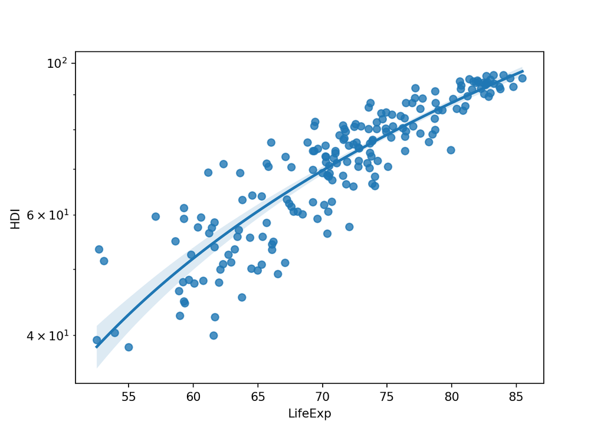

```python
# Variables tranformadas
plt.figure(3)
sns.regplot(data = datos, x="LifeExp", y="HDI");
plt.yscale('log')
plt.show()
```

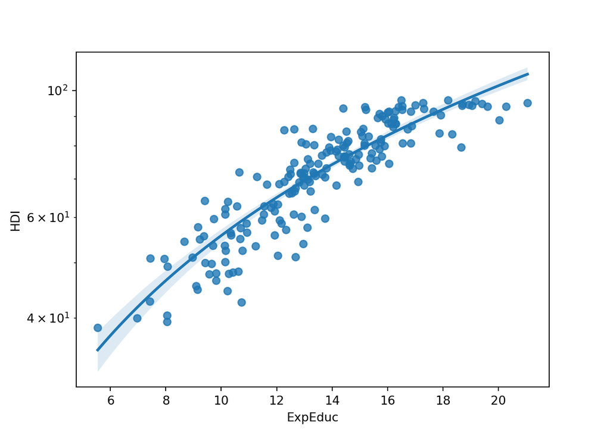

```python
plt.figure(4)
sns.regplot(data = datos, x="ExpEduc", y="HDI");
plt.yscale('log')
plt.show()
```

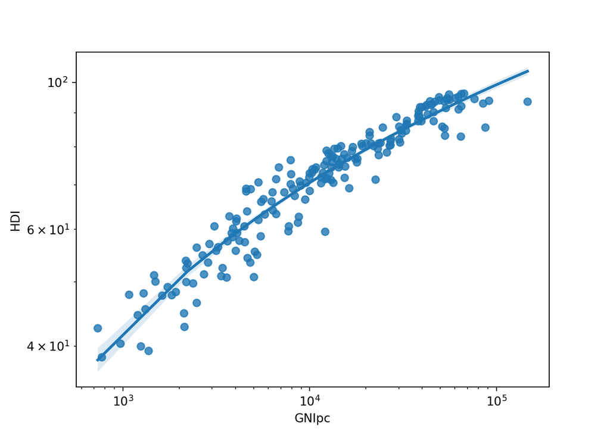

```python
plt.figure(5)
sns.regplot(data = datos, x="GNIpc", y="HDI", logx=True);
plt.xscale('log')
plt.yscale('log')
plt.show()
```

```python
# Regresión por MCO del modelo
# log(HDI) = beta1 + beta2*LifeExp + beta3*ExpEduc + beta4*log(GNIpc) + e
# Interpretación beta2 y beta3: semi-elasticidades
# Interpretación beta4: elasticidad
mod_log = smf.ols(formula = "np.log(HDI) ~ LifeExp + ExpEduc + np.log(GNIpc)",
data = datos).fit()
print(mod_log.summary())
```

```
                            OLS Regression Results
==============================================================================
Dep. Variable:            np.log(HDI)   R-squared:                       0.959
Model:                            OLS   Adj. R-squared:                  0.958
Method:                 Least Squares   F-statistic:                     1445.
Date:                Sun, 28 Apr 2024   Prob (F-statistic):          4.60e-129
Time:                        22:36:30   Log-Likelihood:                 319.11
No. Observations:                 191   AIC:                            -630.2
Df Residuals:                     187   BIC:                            -617.2
Df Model:                           3
Covariance Type:            nonrobust
=================================================================================
                    coef    std err          t      P>|t|      [0.025      0.975]
---------------------------------------------------------------------------------
Intercept         2.5298      0.035     71.703      0.000       2.460       2.599
LifeExp           0.0064      0.001      7.552      0.000       0.005       0.008
ExpEduc           0.0207      0.002     10.072      0.000       0.017       0.025
np.log(GNIpc)     0.1056      0.006     17.657      0.000       0.094       0.117
==============================================================================
Omnibus:                        3.315   Durbin-Watson:                   2.023
Prob(Omnibus):                  0.191   Jarque-Bera (JB):                2.977
Skew:                          -0.298   Prob(JB):                        0.226
Kurtosis:                       3.138   Cond. No.                         781.
==============================================================================

Notes:
[1] Standard Errors assume that the covariance matrix of the errors is correctly specified.
```

```python
# Intervalo de confianza del 95% para los parámetros del modelo
mod_log.conf_int()
```

```
                      0         1
Intercept      2.460240  2.599444
LifeExp        0.004753  0.008115
ExpEduc        0.016627  0.024726
np.log(GNIpc)  0.093809  0.117408
```

```python
# Inferencia estadística: contraste de la hipótesis {beta2<=beta3}
# Test t específico: H_0:{beta2-beta3<=0}
# t_0 = (beta2-beta3-0)/se(beta2-beta3)
b2 = mod_log.params['LifeExp'] # estimación del parámetro beta2
b3 = mod_log.params['ExpEduc'] # estimación del parámetro beta3
varb2 = (mod_log.bse['LifeExp'])**2 # estim. var(beta2)
varb3 = (mod_log.bse['ExpEduc'])**2 # estim. var(beta3)
covb2b3 = mod_log.cov_params().loc['LifeExp', 'ExpEduc'] # estim. cov(beta2,beta3)
se_beta2_menos_beta3 = np.sqrt(varb2 + varb3 - 2 * covb2b3)
t_0 = (b2-b3)/se_beta2_menos_beta3
print("Estadístico t0 = ", t_0.round(3))
```

```
Estadístico t0 =  -5.814
```

```python
df = mod_log.df_resid
pval = 1-sp.stats.t.cdf(t_0, df)
print("p-valor = ", pval.round(3))
```

```
p-valor =  1.0
```

```python
# Test t general de la hipótesis {R*beta (>)(=)(<) r}
# Definición del contraste
def t_test(model, R, r):
  VCOV = model.cov_params()
  b = model.params
  Rbeta = R.T.dot(b)
  varRbeta = R.T.dot(VCOV).dot(R)
  t_0 = (Rbeta - r)/np.sqrt(varRbeta)
  df = model.df_resid
  pval_unilat_izqda = scs.t.cdf(t_0, df)
  pval_bilat = 2*(1 - scs.t.cdf(np.abs(t_0), df))
  pval_unilat_dcha = 1 - scs.t.cdf(t_0, df)
  return(t_0, pval_unilat_izqda, pval_bilat, pval_unilat_dcha)
# Ejecución del contraste
R = np.array([0, 1, -1, 0])
r = 0
p = t_test(mod_log, R, r)
print('Resultados:', '\n',
'Estadístico t0 = ', round(p[0], 4), '\n',
' p-valor unilat_izqda  (Ho: Rbeta >= r)  = ', round(p[1], 4), '\n',
' p-valor bilateral     (Ho: Rbeta = r)   = ', round(p[2], 4), '\n',
' p-valor unilat_dcha   (Ho: Rbeta <= r)  = ', round(p[3], 4))
```

```
Resultados:
 Estadístico t0 =  -5.8143
  p-valor unilat_izqda  (Ho: Rbeta >= r)  =  0.0
  p-valor bilateral     (Ho: Rbeta = r)   =  0.0
  p-valor unilat_dcha   (Ho: Rbeta <= r)  =  1.0
```

```python
# Predicción del HDI para un país con los siguientes indicadores parciales:
# LifeExp = 71.7, ExpEduc = 13.4, GNIpc = 12306.3
nuevo_PAIS = pd.DataFrame({'LifeExp': [71.7], 'ExpEduc': [13.4], 'GNIpc': [12306.3]})
print(nuevo_PAIS)
```

```
   LifeExp  ExpEduc    GNIpc
0     71.7     13.4  12306.3
```

```python
# HDI esperado con intervalo de confianza
pred_log_HDI_IC = mod_log.get_prediction(nuevo_PAIS).summary_frame(alpha=0.05)
print(pred_log_HDI_IC[['mean','mean_ci_lower', 'mean_ci_upper']])
```

```
       mean  mean_ci_lower  mean_ci_upper
0  4.262828       4.256127        4.26953
```

```python
pred_HDI_IC=np.exp(pred_log_HDI_IC)
print(pred_HDI_IC[['mean','mean_ci_lower', 'mean_ci_upper']])
```

```
       mean  mean_ci_lower  mean_ci_upper
0  71.01054      70.536244      71.488024
```